# Control Struictures in R

R에서 식 흐름의 실행을 제어하기 위해 제어 구조를 사용합니다. 이러한 제어 구조는 R에서 루프(Loop)라고도합니다. R에는 8 가지 유형의 제어 구조가 있습니다.:

•if •if-else •for •nested loops •while •repeat and break •next •return

We will study their examples as well as its execution flow.

## Control Structures in R Programming

R은 우리의 요구 사항에 대한 다양한 표준 제어 구조를 제공합니다.

expr 표현식은 중괄호 {}로 묶을 수있는 여러 명령문으로 구성됩니다.

[figure not shown]

### 1. if Condition in R

This task is carried out only if this condition is returned as TRUE. R makes it even easier: You can drop the word then and specify your choice in an if statement.

> if (test_expression) {

> statement

> }

```r
for(values in 1:10)
{if (values <= 10)
print(paste(values, "is less than or equal to 10"))
}
```

```
## [1] "1 is less than or equal to 10"
## [1] "2 is less than or equal to 10"
## [1] "3 is less than or equal to 10"
## [1] "4 is less than or equal to 10"
## [1] "5 is less than or equal to 10"
## [1] "6 is less than or equal to 10"
## [1] "7 is less than or equal to 10"
## [1] "8 is less than or equal to 10"
## [1] "9 is less than or equal to 10"
## [1] "10 is less than or equal to 10"
```

```r
for(values in 1:10)
{if (values <= 5)
print(paste(values, "is less than or equal to 5"))
}
```

```
## [1] "1 is less than or equal to 5"
## [1] "2 is less than or equal to 5"
## [1] "3 is less than or equal to 5"
## [1] "4 is less than or equal to 5"
## [1] "5 is less than or equal to 5"
```

- 한줄로 표현된 경우 {}을 생략해도 괜찮습니다.

### 2. if-else Condition in R

An if…else statement contains the same elements as an if statement (see the preceding section), with some extra elements

- else는 앞의 if문이 참이 아닐때 실행됩니다.

> if (test_expression) {

> statement

> } else {

> statement

> }

```r
x <- -4
if(x > 0) # 조건을 만족하지 않으므로 else문이 실행됩니다.
  { print("양수입니다.")
} else {
  print("양수가 아닙니다.")
}
```

```
## [1] "양수가 아닙니다."
```

아래와 같이 사용하면 오류가 발생하고 실행되지 않습니다.

```r
x <- -4
if(x > 0) # 조건을 만족하지 않으므로 아래의 문장이 실행되지 않습니다.
  print("양수입니다.")
 } else
   {print("양수가 아닙니다.")}
```

하지만 아래와 같이 else 다음에 한줄로 된 코드를 입력하면 문제 없이 실행됩니다.

```r
x <- -4
if(x > 0) # 조건을 만족하지 않으므로 아래의 문장이 실행되지 않습니다.
 { print("양수입니다.")
 } else print("양수가 아닙니다.")
```

```
## [1] "양수가 아닙니다."
```

#### if…else Ladder

조건을 만족하거나, 만족하지 않거나 처럼 2개의 선택이 아닌 여러 선택이 있는 경우에는 else if {}를 이용하자.

> if ( test_expression1) {

> statement1

> } else if ( test_expression2) {

> statement2 } else if ( test_expression3) {

> statement3

> } else {

> statement4

> }

```r
x <- 0
if (x < 0) {
print("Negative number")
} else if (x > 0) {
print("Positive number")
} else
print("Zero")
```

```
## [1] "Zero"
```

## 3. for Loop in R

A loop is a sequence of instructions that is repeated until a certain condition is reached. for, while and repeat, with the additional clauses break and next are used to construct loops.

> values <- c(1,7,5,3,9)

> for(id in 1:5){

> print(values[id])

> }

Q1. if와 for를 이용하여 50부터 100까지 6의 배수의 합을 구하여라.

```r
sum=0
for(i in 50:100){
if(i %% 6==0) sum=sum+i
}
print(sum)
```

```
## [1] 600
```

Q2. 2,5,3,9,8,11,6에서 짝수의 갯 수를 if와 for 문으로 구하여라.

```r
x <- c(2,5,3,9,8,11,6)
count <- 0
for (val in x) {
if(val %% 2 == 0)  count = count+1
}
print(count)
```

```
## [1] 3
```

Q3. 10!을 계산하세요.

```r
x <- 1:10
count <- 1
for (val in x) {
count = count*val
}
print(count)
```

```
## [1] 3628800
```

- for와 if는 Data를 원하는대로 핸들링하는데 가장 많이 사용되는 제어문입니다.
- for문안에 for를 또 사용할 수 있습니다. (Nested for)

Q4. 구구단표 만들기

```r
for(i in 1:3){
  for(j in 1:3){
    print(paste(i,"*",j,"=",i*j))
  }
}
```

```
## [1] "1 * 1 = 1"
## [1] "1 * 2 = 2"
## [1] "1 * 3 = 3"
## [1] "2 * 1 = 2"
## [1] "2 * 2 = 4"
## [1] "2 * 3 = 6"
## [1] "3 * 1 = 3"
## [1] "3 * 2 = 6"
## [1] "3 * 3 = 9"
```

Q5. 숫자를 입력받고 해당 숫자가 홀수 있지 짝수 인지 구분하는 코드는?

```r
myfunt1 <- function(){
 print("Enter an integer or whole number : ")
 enter <- as.integer(readline(prompt = ""))
 if(enter %% 2 == 0) print("짝수입니다.")
 else print("홀수입니다.")
}

myfunt2 <- function(enter){
 if(enter %% 2 == 0) print("짝수입니다.")
 else print("홀수입니다.")
}

myfunt2(43)
```

```
## [1] "홀수입니다."
```

```r
myfunt2(554)
```

```
## [1] "짝수입니다."
```

Q6. 숫자를 입력받고 해당 숫자까지 존재하는 짝수를 출력하는 코드는?

```r
myfunt3 <- function(enter){
 if(enter<=0) print("입력된 값이 0보다 작거나 같습니다.")
  else {
    for(i in 1:enter)
    if(i %%2 ==0) print(i)
 }
}

myfunt3(-5)
```

```
## [1] "입력된 값이 0보다 작거나 같습니다."
```

```r
myfunt3(15)
```

```
## [1] 2
## [1] 4
## [1] 6
## [1] 8
## [1] 10
## [1] 12
## [1] 14
```

Q7. 숫자를 입력하여 그 숫자가 짝수이면 해당되는 개수의 짝수를 출력하고, 그 숫자가 홀수이면 해당되는 개수의 홀수를 출력하는 코드는?

예) 5를 입력하면 1,3,5,7,9 8을 입력하면 2,4,6,8,10,12,14,16

```r
myfunt4 <- function(enter){
 if(enter<=0) print("입력된 값이 0보다 작거나 같습니다.")
  else if(enter %%2 ==0){
  print(seq(2,2*enter,2))
  } else if(enter %%2 ==1){
  print(seq(1,2*enter,2))
 }
}

myfunt4(5)
```

```
## [1] 1 3 5 7 9
```

```r
myfunt4(8)
```

```
## [1]  2  4  6  8 10 12 14 16
```

Q8. *로 직각 삼각형 만들기

```r
myfunt5 <- function(enter){
  for(i in 1:enter){
    cat(paste(c(rep("*",i),"\n")))
  }
}
myfunt5(9)
myfunt6 <- function(enter){
  for(i in seq(enter,1,-1)){
    cat(paste(c(rep("*",i),"\n")))
  }
}
myfunt6(9)
```

[output not shown]

Q9. 지구의 공전주기는 365가 아니므로 4년에 한번씩 윤년이 생깁니다. 1. 연도가 4로 나누어지면 윤년(2월이 29일) 2. 연도가 100으로 나누어지면 윤년이 아님 (2월 28일) 3. 연도가 1000으로 나누어지면 윤년 (2월 29일)

임의의 년도를 입력하여 윤년인지 윤년이 아닌지 답해주는 프로그램을 만들어보자.

예를 들어 2000은 1000으로 나누어지므로 윤년이고, 2100년은 100으로 나누어지므로 윤년이 아니다. 2020년은 윤년이고 2021년은 윤년이 아니다.

```r
cal.f <- function(year){

  if(year %% 4 ==0 & year %% 100 ==0 & year %% 1000 ==0){
  print("leap year")
  } else if(year %% 4 ==0 & year %% 100 ==0 & year %% 1000 !=0){
  print("normal year")
  } else if(year %% 4 ==0 & year %% 100 !=0){
  print("leap year")
 } else {
  print("normal year")
} #end else
} # end if

cal.f(2000)
```

```
## [1] "leap year"
```

```r
cal.f(2100)
```

```
## [1] "normal year"
```

```r
cal.f(2020)
```

```
## [1] "leap year"
```

```r
cal.f(2021)
```

```
## [1] "normal year"
```

## 4. while Loop in R

while문은 for문과 비슷하지만 조건을 만족할때만 반복 수행된다.

for문은 정해진 조건만 반복 수행한다.

```r
 val = 5
 while(val <= 10) {
  val = val + 1.1
  print(val)
 }
```

```
## [1] 6.1
## [1] 7.2
## [1] 8.3
## [1] 9.4
## [1] 10.5
```

## 5. break statement in R

We use break statement inside a loop (for, while) to stop the iterations and flow the control outside of the loop. While in a nested looping situation, where there is a loop inside another loop, this statement exits from the innermost loop that is being evaluated.

```r
values = 1:10
for (id in values){
  if (id == 2){
    break #for문을 강제 종료
  }
  print(id)
}
```

```
## [1] 1
```

```r
values = 1:10
for (id in values){
  if (id == 2){
    print("입력된 수는 2입니다.") #종료되지 않으므로 for문이 끝날때까지 계속 수행
  }
  print(id)
}
```

```
## [1] 1
## [1] "입력된 수는 2입니다."
## [1] 2
## [1] 3
## [1] 4
## [1] 5
## [1] 6
## [1] 7
## [1] 8
## [1] 9
## [1] 10
```

## 6. next statement in R

next jumps to the next cycle without completing a particular iteration. In fact, it jumps to the evaluation of the condition holding the current loop. Next statement enables to skip the current iteration of a loop without terminating it.

- break처럼 강제종료하지 않고 다음으로 넘어 갈려면?

```r
x = 1: 4
for (i in x) {
if (i == 2) {
next
} # 다음 i로 넘어가므로 밑의 print(i)가 실행되지 않음
print(i)
}
```

```
## [1] 1
## [1] 3
## [1] 4
```

## 7. return statement in R

Many times, we will require some functions to do processing and return back the result. This is accomplished with the return() statement in R.

함수 안의 결과를 밖에서 사용하고자 할때 사용됨.

```r
check <- function(x) {
if (x > 0) {
result <- "Positive"
} else if (x < 0) {
result <- "Negative"
} else {
result <- "Zero"
}
return(result)
}
a <- check(10)
b <- check(-5)
c <- check(0)
a
```

```
## [1] "Positive"
```

```r
b
```

```
## [1] "Negative"
```

```r
c
```

```
## [1] "Zero"
```

Q10. *로 피라미드 그리기

```r
myfunt7 <- function(enter){
  for(i in 1:enter){
    j = enter-i
    blank <-paste0(c(rep(c(" "),j),rep("*",i*2-1),rep(c(" "),j),"\n") )
    cat(blank)
    }
}

myfunt7(5)
myfunt7(7)
```

[output not shown]

## 혼자 해보기

#### 1. n을 입력받가 n보다 작은 3의 배수와 5의 배수의 합 구하기(for, if, function 이용)

#### 2. 1~100까지 숫자 중 3과 4의 공배수를 구하여 출력하기 (for와 if 사용)

#### 3. 위의 Q10을 이용하여 아래와 같은 다이아몬드 그림 그리기 (for, if 사용)

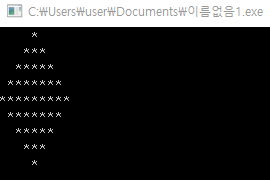